# Gráficos con ggplot2: Primeras ideas

Módulo práctico de ITA  
(Grupo M)

Pedro J. Pérez

pedro.j.perez@uv.es

## Gráficos chulos con *ggplot2*

Uno de los mejores (que dices!?, el MEJOR!!!) sistema gráfico del MUNDO.

## el análisis gráfico es fundamental

- El **análisis gráfico es fundamental** al presentar resultados, pero también en el análisis exploratorio: permite descubrir relaciones entre variables, y descartar o sugerir nuevas preguntas sobre los datos.

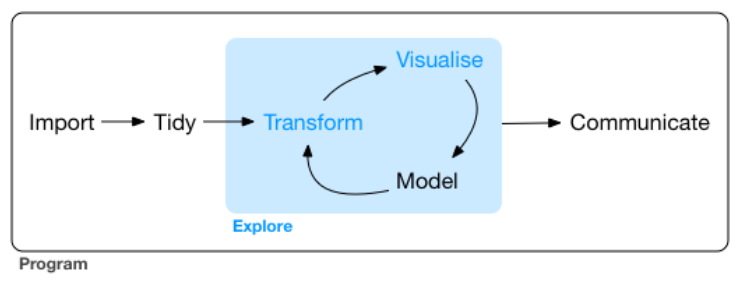

- R tiene varios sistemas gráficos, pero **usaremos ggplot2** porque ahora mismo **es el estándar**
- *ggplot2* es un paquete de R para producir gráficos estadísticos.
- Bueno, en realidad **es todo un ecosistema**. Mira sus extensiones [[aquí]](https://exts.ggplot2.tidyverse.org/gallery/).

## usaremos los datos de `iris`

- En estas slides usaremos `iris`, unos datos que **vienen con R**: no hay que cargarlos, ya están ahí
- Son las medidas de **150 flores** de lirio (*iris* en inglés) de **3 especies**: *setosa*, *versicolor* y *virginica* (50 de cada)
- Tienen 5 variables: el largo y el ancho del **sépalo** (`Sepal.Length`, `Sepal.Width`) y del **pétalo** (`Petal.Length`, `Petal.Width`), en cm, y la **especie** (`Species`)

¿Te acuerdas de `slice()`? Así vemos un par de flores de cada especie:

```r
iris %>%
  slice(c(1, 2, 51, 52, 101, 102)) %>%
  gt::gt()
```

| Sepal.Length | Sepal.Width | Petal.Length | Petal.Width | Species |
| --- | --- | --- | --- | --- |
| 5.1 | 3.5 | 1.4 | 0.2 | setosa |
| 4.9 | 3.0 | 1.4 | 0.2 | setosa |
| 7.0 | 3.2 | 4.7 | 1.4 | versicolor |
| 6.4 | 3.2 | 4.5 | 1.5 | versicolor |
| 6.3 | 3.3 | 6.0 | 2.5 | virginica |
| 5.8 | 2.7 | 5.1 | 1.9 | virginica |

## ¿qué vemos en el gráfico de abajo?

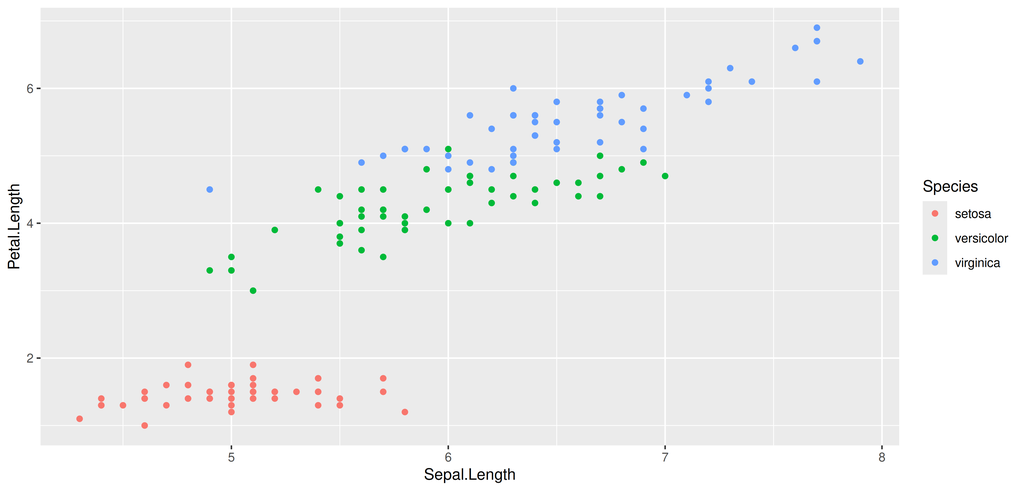

- gráfico de puntos
- se representan 3 variables:
  - Sepal.Length en el **eje X**
  - Petal.Length en el **eje Y**
  - Species en el **color de los puntos**

Importante para entender ggplot2 [ 🌟 ]

Un gráfico tiene 3 componentes principales:

- los **datos** que se van a representar (ggplot() )
- un conjunto de **propiedades estéticas asociadas a variables** del conjunto de datos. Por ejemplo, la posición en el eje X está asociada a la variable Sepal.Length, el color de los puntos está asociado a los valores de la variable Species. ( aes() )
- el **elemento geométrico que se va a representar**. En nuestro caso son puntos (geom_point() ), pero podrían haber sido las líneas (geom_line() ) o …

## sintaxis de ggplot2 [ 🌟 ]

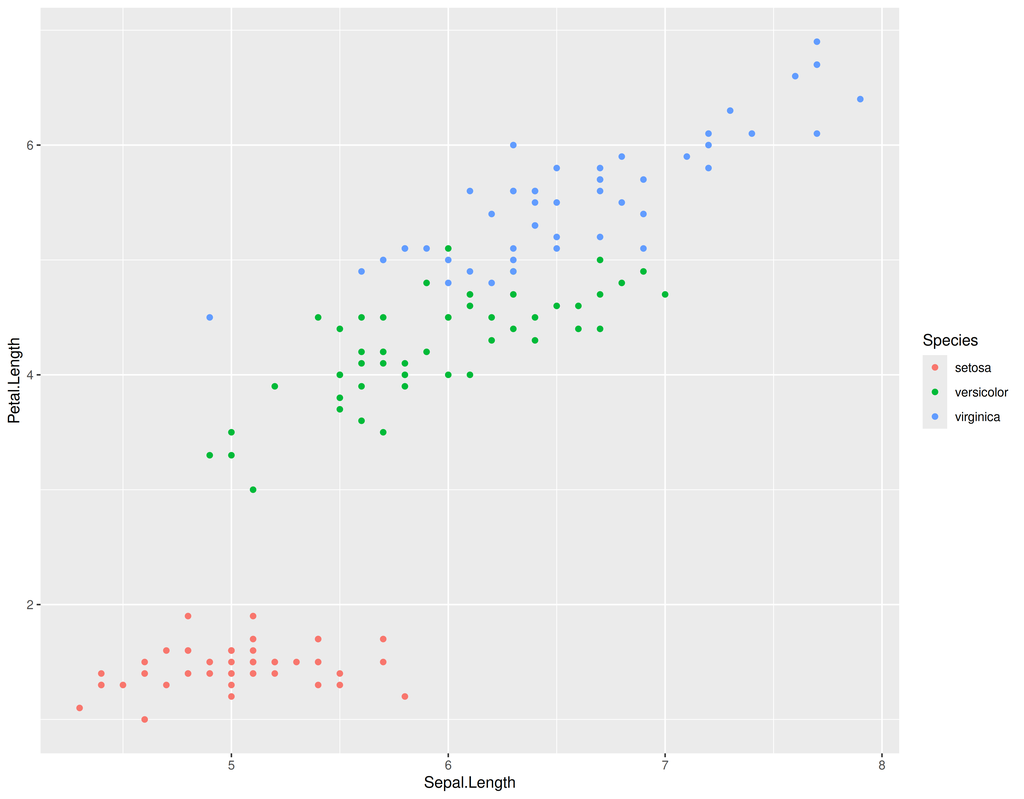

```r
ggplot(data = iris, aes(x = Sepal.Length,
                        y = Petal.Length,
                        color = Species)) +
    geom_point()
```

## Gráfico en slow-motion!

```r
iris %>%
```

```r
iris %>%
ggplot() +
```

```r
iris %>%
ggplot() +
   aes(x = Sepal.Length) +
```

```r
iris %>%
ggplot() +
   aes(x = Sepal.Length) +
   aes(y = Petal.Length) +
```

```r
iris %>%
ggplot() +
   aes(x = Sepal.Length) +
   aes(y = Petal.Length) +
   aes(color = Species)  +
```

```r
iris %>%
ggplot() +
   aes(x = Sepal.Length) +
   aes(y = Petal.Length) +
   aes(color = Species)  +
  geom_point()
```

```
#>   Sepal.Length Sepal.Width Petal.Length Petal.Width Species
#> 1          5.1         3.5          1.4         0.2  setosa
#> 2          4.9         3.0          1.4         0.2  setosa
#> 3          4.7         3.2          1.3         0.2  setosa
#> 4          4.6         3.1          1.5         0.2  setosa
#> 5          5.0         3.6          1.4         0.2  setosa
#> 6          5.4         3.9          1.7         0.4  setosa
```

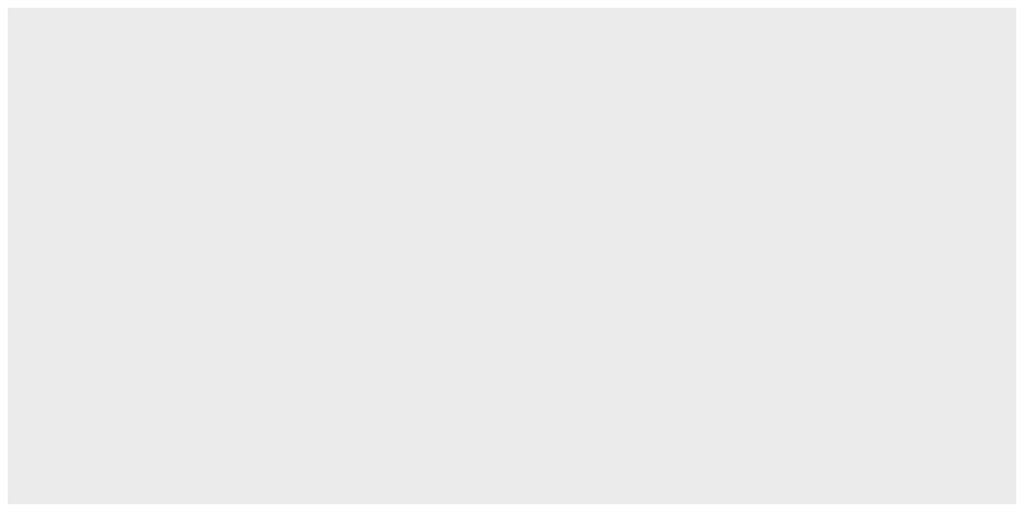

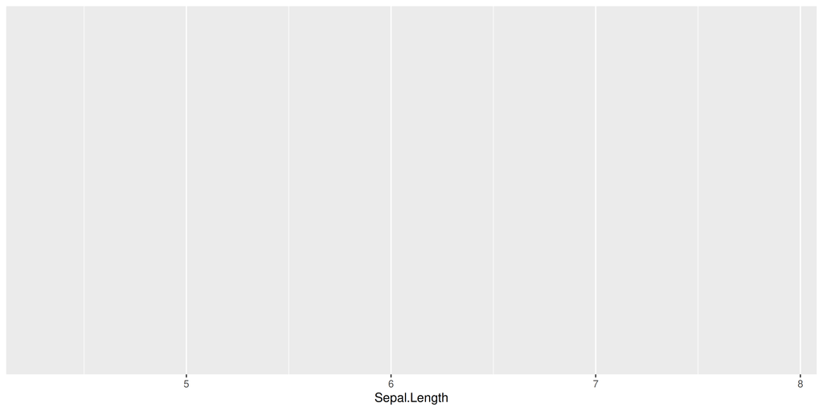

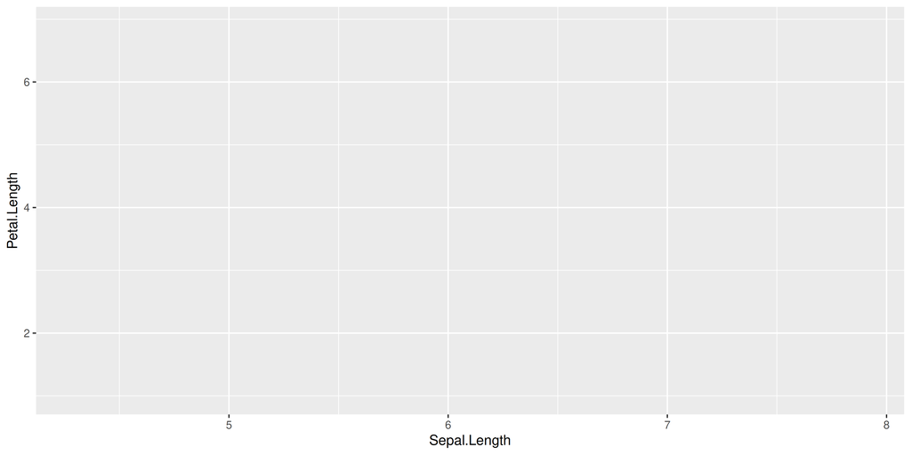

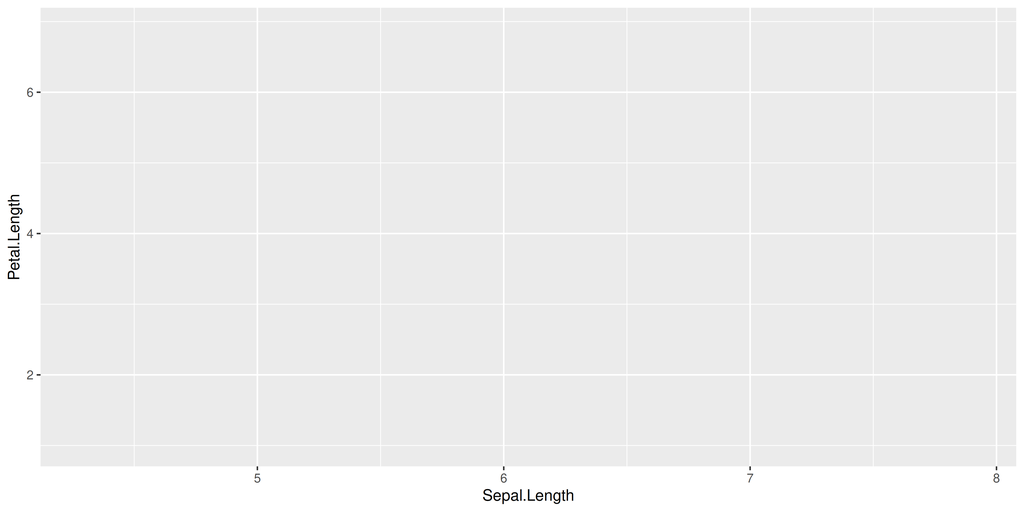

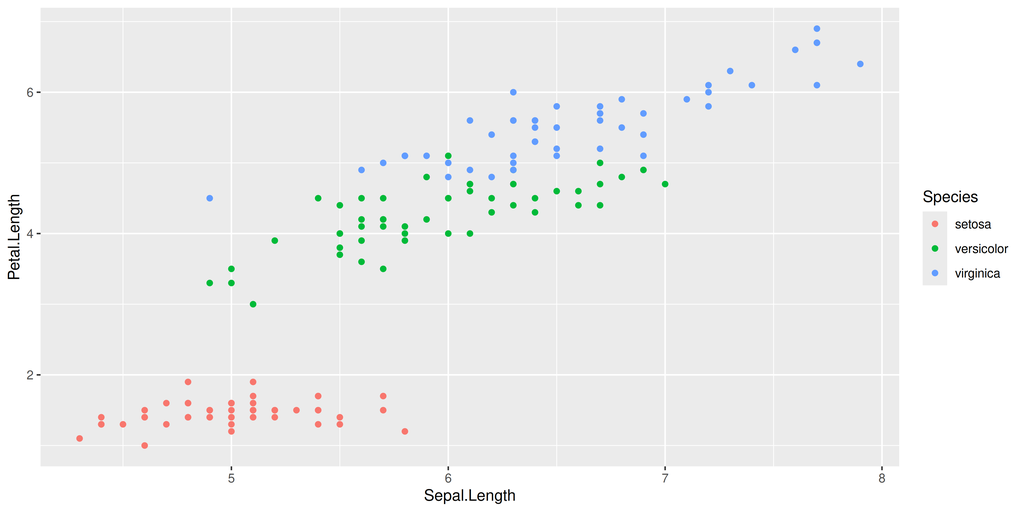

La forma habitual(!) de escribirlo es:

```r
ggplot(data = iris,
       aes(x = Sepal.Length,
           y = Petal.Length,
           color = Species)) +
    geom_point()
```

## IMAGINA qué hacen las siguientes instrucciones. Después las ejecutas.

- Tarea
- 1
- 2
- 3
- 4

```r
#- Fíjate: sólo hay 2 variables en aes() --
ggplot(data = iris, aes(x = Sepal.Length, y = Petal.Length)) +
  geom_point()

#- Fíjate: ahora usamos geom_line() --
ggplot(data = iris, aes(x = Sepal.Length, y = Petal.Length)) +
  geom_line()

#- Fíjate: ahora usamos 2 geom_xx() --
ggplot(data = iris, aes(x = Sepal.Length, y = Petal.Length)) +
  geom_point() + geom_smooth()

#- Fíjate: ahora hay argumentos dentro de geom_point(). Uno de ellos es `color` --
ggplot(data = iris, aes(x = Sepal.Length, y = Petal.Length)) +
  geom_point(color = "red", size = 2, alpha = 0.2)
```

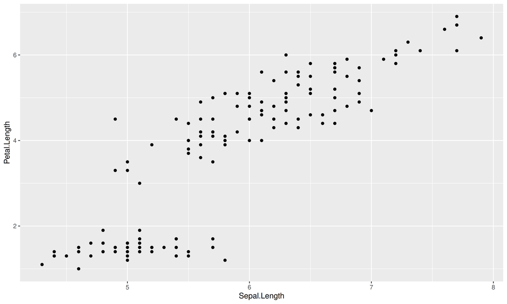

```r
ggplot(data = iris, aes(x = Sepal.Length, y = Petal.Length)) +
  geom_point()
```

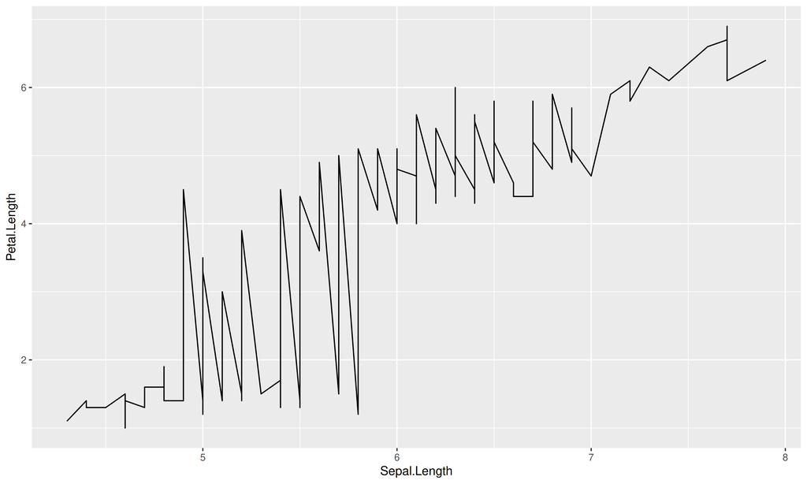

```r
ggplot(data = iris, aes(x = Sepal.Length, y = Petal.Length)) +
  geom_line()
```

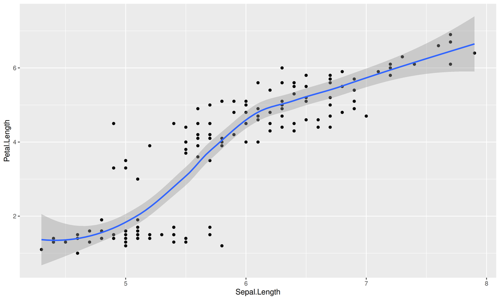

```r
ggplot(data = iris, aes(x = Sepal.Length, y = Petal.Length)) +
  geom_point() + geom_smooth()
```

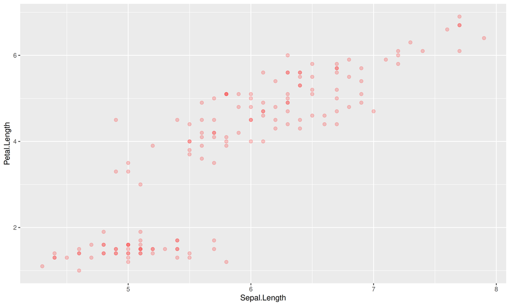

```r
ggplot(data = iris, aes(x = Sepal.Length, y = Petal.Length)) +
  geom_point(color = "red", size = 2, alpha = 0.2)
```

## Entendiendo un poco más *ggplot2*

Ya tenemos las primeras ideas sobre ggplot2, ahora se trata de profundizar un poco para que podamos tener más control y flexibilidad al hacer nuestros gráficos.

## vamos a profundizar un poco más en *ggplot2*

Es importante que veas que estas 3 expresiones **hacen el mismo gráfico**:

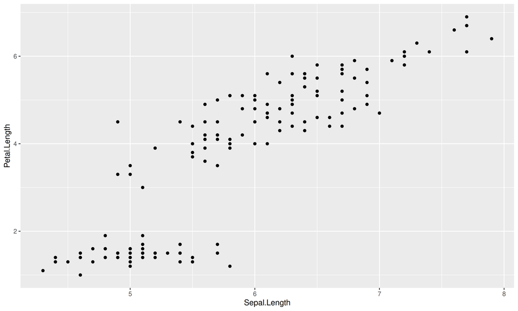

```r
ggplot(data = iris, aes(x = Sepal.Length, y = Petal.Length)) +
  geom_point()

ggplot(data = iris) +
  geom_point(aes(x = Sepal.Length, y = Petal.Length))

ggplot() +
  geom_point(data = iris, aes(x = Sepal.Length, y = Petal.Length))
```

- Bueno, sí ¿Y qué más da? Pues importa y muuuuccho.
- Esto **nos va a dar mucha flexibilidad**/control a nuestros gráficos. Lo veremos

## ¿qué hacen estas 3 expresiones?

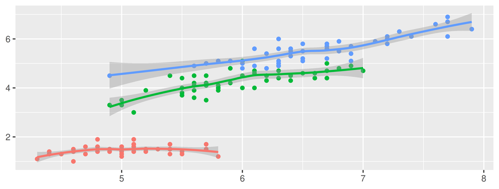

```r
ggplot(data = iris, aes(x = Sepal.Length, y = Petal.Length, color = Species)) +
  geom_point() + geom_smooth()
```

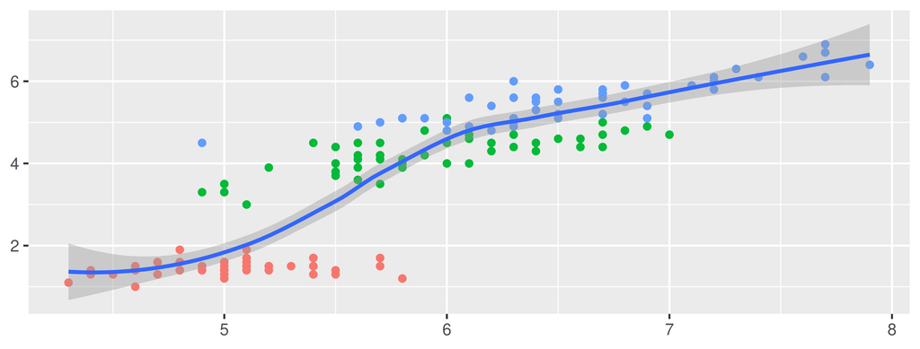

```r
ggplot(data = iris, aes(x = Sepal.Length, y = Petal.Length)) +
  geom_point(aes(color = Species)) + geom_smooth()
```

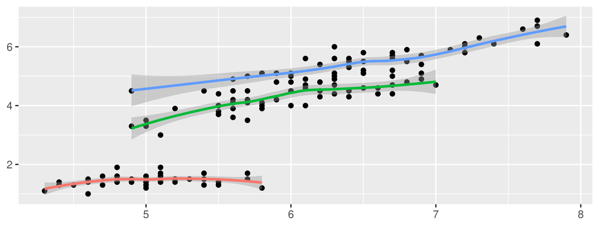

```r
ggplot(data = iris, aes(x = Sepal.Length, y = Petal.Length)) +
  geom_point() + geom_smooth(aes(color = Species))
```

## ¿por qué no funciona esta expresión?

```r
ggplot() +
  geom_point(data = iris,
             aes(x = Sepal.Length, y = Petal.Length)) +
   geom_line(aes(x = Sepal.Length, y = Petal.Length))
```

```
#> Error in `geom_line()`:
#> ! Problem while computing aesthetics.
#> ℹ Error occurred in the 2nd layer.
#> Caused by error:
#> ! objeto 'Sepal.Length' no encontrado
```

- `geom_line()` no sabe qué datos usar: `iris` solo se ha indicado dentro de `geom_point()`, no en `ggplot()`

## Mapear vs fijar: ¿dentro o fuera de `aes()`? [ 🌟 ]

**Mapear** (dentro de `aes()`): el color **depende de una variable** → ggplot2 crea una leyenda

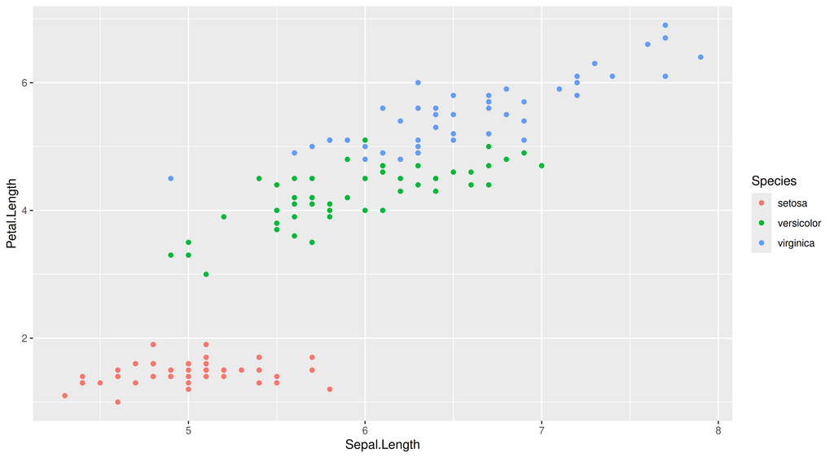

```r
ggplot(data = iris,
       aes(x = Sepal.Length, y = Petal.Length)) +
  geom_point(aes(color = Species))
```

**Fijar** (fuera de `aes()`): el color es **un valor fijo** para todos los puntos → no hay leyenda

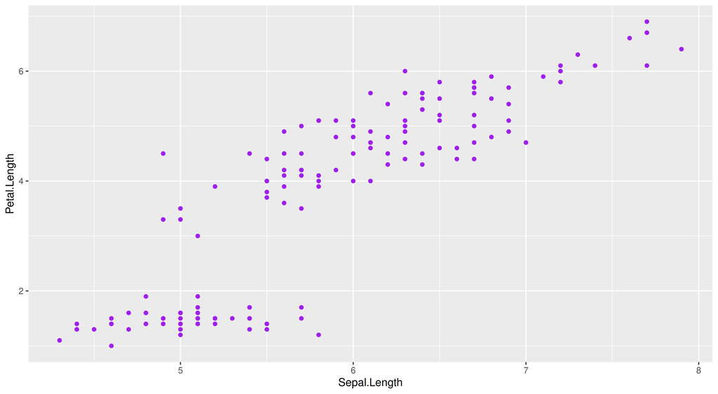

```r
ggplot(data = iris,
       aes(x = Sepal.Length, y = Petal.Length)) +
  geom_point(color = "purple")
```

## ¿veremos alguna vez otros gráficos?

- SÍ!!!! en las siguientes slides haremos gráficos de **líneas**, de **puntos (X-Y)** y de **barras**. Y ya no con `iris`, sino con los datos de gapminder
- Si no puedes esperarte ve a la [R Graph Gallery](https://r-graph-gallery.com/) o a la galería de [extensiones de ggplot2](https://exts.ggplot2.tidyverse.org/gallery/)

para hacer otros gráficos tendremos que usar otros **geom_xx()**

**Por ejemplo**:

- `geom_line()`
- `geom_bar()`
- `geom_col()`
- `geom_density()`
- `geom_path()`
- `geom_map()`
- `geom_raster()`
- `geom_rug()`
- … y muchos más

## Resumen

Todo lo que hemos visto, en un solo gráfico:

```r
ggplot(data = iris,
       aes(x = Sepal.Length,
           y = Petal.Length)) +
  geom_point(aes(color = Species),
             size = 3)
```

**1**

Los **datos**

**2**

Las **estéticas**: qué variable va en cada eje. Como están en `ggplot()`, valen para todos los geoms

**3**

Las partes del gráfico se van añadiendo **con `+`**

**4**

El **geom**: puntos. Con `color` **dentro** de `aes()`, el color depende de una variable

**5**

Con `size` **fuera** de `aes()`, el tamaño es un valor fijo, el mismo para todos los puntos

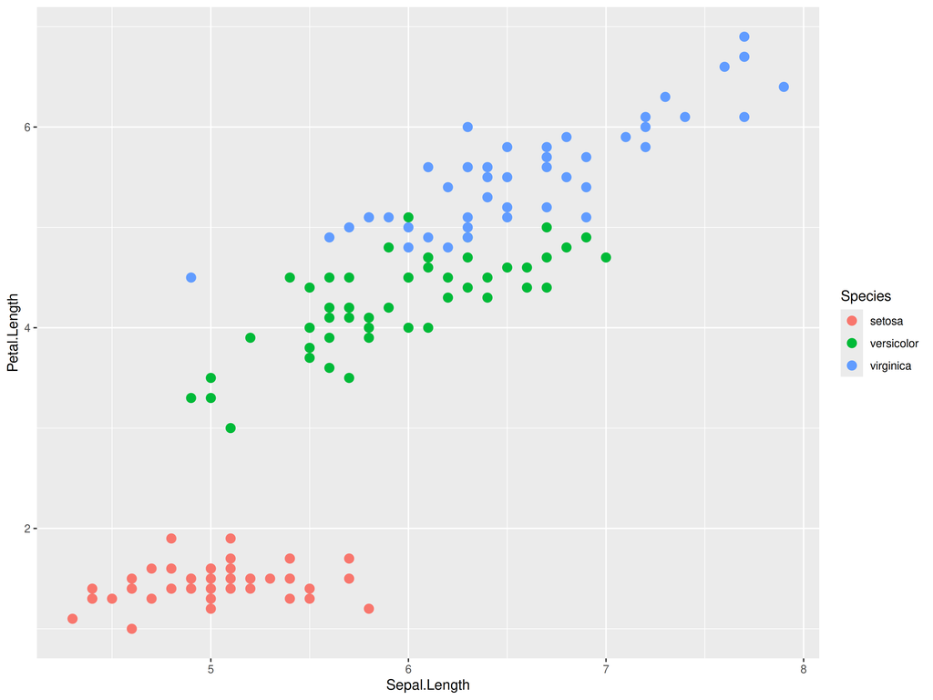

Para hacer otros tipos de gráficos usaremos otros `geom_xx()`: `geom_line()`, `geom_col()`, … Lo veremos en las siguientes slides